# 경금_최종_2021155151_이준희-Copy1

## 지역적 특성 중심의 주택(아파트) 가격 예측

##### - Connecticut 주 Hartford 시의 공공데이터 중심으로 -

##### 2021155151_이준희

### 목차

#### 1. 서론

```
  1.1 선행연구
  1.2 연구 배경 & 목적
```

#### 2. 데이터 수집 & 전처리

```
  2.1 Open API
  2.2 데이터 설명 & 특징
  2.3 전처리 및 시각화
```

#### 3. 모형 설명

```
  3.1 회귀분석
  3.2 트리 기반 알고리즘
  3.3 평가지표
```

#### 4. 결과

```
  4.1 변수 선택
  4.2 회귀 진단
  4.3 모형 선택
  4.4 중요도 분석
```

#### 5. 결론

```
  5.1 결론
  5.2 한계
  5.3 향후 연구 방향
```

### 1. 서론

- 선행연구
- 연구 배경 & 목적

주택 가격에 대한 예측은 주가 및 환율과 마찬가지로 다양한 요인으로부터 영향을 받는다. 나아가 주택 가격을 다루는 부동산 시장은 단순히 사람들의 생활수준에 대한 내수 경제의 흐름만을 보여주지 않는다. 보다 깊은 측면에서 한 국가의 경제와 상호보완적 관계를 형성하고 경제적 안정성을 일부 보여줄 수 있다. 예를 들어, 주택 가격의 상승과 하락을 통해서 물가와 환율의 추세를 일정 부분 확인할 수 있고 나아가 소비자들의 자산 규모에 대한 측정 역할도 함께 할 수 있다. 이러한 특성에 따라, 부동산 분야에서의 빅데이터 활용이 점차 활발해지고 있고 그 중 가장 대표적인 것이 주택 가격의 시세 및 변동 예측이다. 주택 가격의 예측은 전통적인 회귀분석과 더불어 최근에 여러 분야에서 각광을 받는 머신러닝 및 딥러닝 기법 또한 많이 적용되고 있다. 국내에서는 매매 및 임대 중개 관련해서 부동산 관련 데이터 플랫폼이 주를 이루고 있으며 주택의 시세를 예측하는 분야는 아직 발전하는 단계이다. 본 연구는 후자에 가까운 주택 가격 예측에 대한 분석을 시행했고 예측의 성능과 주요 요인들을 함께 비교분석했다. 해당 연구를 진행하기에 앞서 살펴본 선행연구에서 이를 설명하면 다음과 같다.

#### 1-1. 선행연구

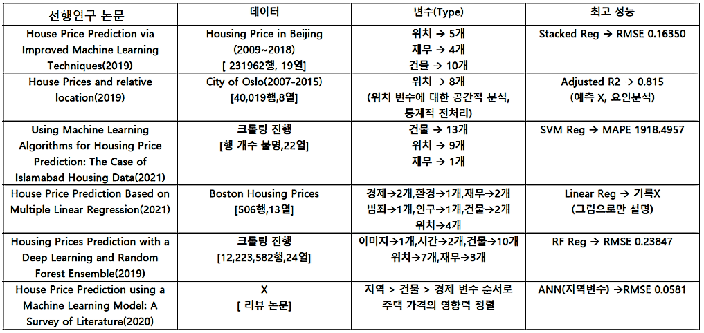

```python
from IPython.display import Image
Image('경금 자료/선행연구.png')
```

선행연구 조사로 총 6개의 논문을 선정하였다. 이중 5개는 각각의 데이터의 활용을 통해서 결과 및 해석을 나열했고 마지막 1개는 해당 분야의 연구들에 대한 리뷰를 담았다.

첫 번째 논문인 House Price Prediction via Improved Machine Learning Tecniques(2019)은 RandomForest, Gradient Boosting, Light GBM, Hybrid, Stacked Regression을 이용해서 주택 가격을 예측했다. 여기서 사용된 데이터는 베이징의 약 10년치 주택가격이며 다양한 종류의 변수를 이용했다. 위치와 건물, 재무적 요소가 골고루 섞여 있었고 특히 이 중 위치와 건물 변수에는 건물의 연식, 면적, 내부 시설 및 역세권 여부 등 상당히 구체적인 정보가 많았다. 또한, 이 정보에 대한 시각화를 통해서 가격과의 연관성을 파악한 결과, 주택 가격이 기본적으로 위치와 건물 특성에 많은 영향을 받는 것을 확인했다. 이것은 데이터가 가진 가격에 대한 주요 변수들의 다양성과 이들의 높은 설명력을 강조한다. 이후 제시된 회귀 모형 중 최종으로 Stacked Generalizaiton Regression이 가장 좋은 성능인 RMSLE 0.16350을 나타냈다.

House Prices and relative location(2019)은 예측을 통한 성과 비교보다 전통적인 회귀분석을 통한 요인 탐지 중심의 논문이다. 특히, 파키스탄의 Olso시의 지리적 특성 속 다양한 시설과 거리, 접근성을 지도를 활용한 공간정보 분석으로 구체적으로 나타냈다. 여러 특성을 고려한 전처리 이후의 R2 값들을 나열한 결과, 가장 높은 값은 0.815로 나왔으며 이 때의 설명변수들은 전처리를 통해서 세부적으로 구간화 및 분리된 변수들이였다. 즉, in-sample 분석에서 구체적인 변수 탐색 및 조정을 거친 높은 R2값을 통해서 지역적 특성을 최대한 구체적으로 활용하고자 시도한 연구였다.

Using Machine Learning Algorithms for Housing Price Prediction: The Case of Islamabad Housing Data는 앞의 두 연구와 다르게 크롤링으로 데이터를 수집했다. 변수들은 지역 인접 편의시설과 건물의 특징 중심으로 이루어졌고 8개의 회귀모형을 사용했다. 이 중, 여러가지 상황에서 보다 경건한 예측 성능을 보여주는 Bayesian Regression, Passive Aggressive Regression, Theil-Sen Regression도 함께 사용됐다. 성능들의 경우 데이터 특성 및 전처리의 영향으로 인해서 다른 선행연구에 비해 오차가 컸지만, 단순히 성능 비교에 그치는 것이 아니라 수집된 데이터 활용의 개선방안과 기여에 보다 집중했다.

Housing Prices Prediction with a Deep Learning and Random Forest Ensemble(2019)는 앞선 논문들에 비해서 매우 방대한 양의 데이터를 확보하고 데이터는 건물 특성이 중심을 이루었다. 또한, 단순히 수치형 변수만 사용한 것이 아닌, 텍스트 및 이미지 데이터를 활용한 딥러닝 모델을 이용한 점에서 차별성 및 발전된 모습을 보였다. 특히 특정 딥러닝 기반 알고리즘을 앙상블 모형과 결합하여 좋은 성능을 보였다. 이것은 기존의 수치형 변수 뿐만 아니라 다른 유형의 데이터의 활용을 가능하게 하기 위한 알고리즘 기반 접근법의 유연함과 성능의 증가를 강조했다.

마지막 리뷰 논문인 House Price Prediction using a Machine Learning Model: A Survey of Literature(2020)은 일반적으로 주택 가격 예측에서의 머신러닝에서의 주요 변수 특징을 나열했다. 이 중 가장 성능에 영향을 크게 끼치고 빈번하게 사용된 특성은 지역적 요인으로 나타났다. 그 다음은 건물의 구조적 특성 및 주변 환경이였으며 수입 등의 경제적 변수는 거의 사용되지 않았다. 또한, 지역적 특성 중심의 데이터를 사용했을 때 전통적인 회귀분석과 각종 머신러닝 기반의 앙상블 및 SVM 회귀 대비 신경망 기반의 모형의 우수성을 보였다.

#### 1-2. 연구 배경 & 목적

연구의 배경은 다음과 같다. 주택은 인간의 의식주가 이루어지는 공간이고 건축 및 환경 기술의 발달로 인하여 사람들의 요구 사항은 점차 증가하고 있다. 나아가 최근에 구매자 뿐만 아니라 투자자에게도 주목을 받고 있다. 이 때, 주택 가격은 보통 일반적인 경제 및 부동산 지표 등의 요소보다 해당 지역의 특성에 가장 영향을 많이 받고 사람들 역시 이 부분을 최우선시한다. 여기서 지역의 특성에는 흔히 교통의 편리함 및 접근성, 교육 및 편의 시설의 분포 등 사람들의 생활 수준에 직접 영향을 끼치는 셀 수 없이 많은 요소들이 포함된다.

선행 연구 속 데이터들의 공통된 특징을 보면, 생각보다 경제 및 금융, 그리고 부동산 관련 변수들은 중요성이 낮았고 공간 정보에 해당하는 지역 혹은 건물의 특성을 가진 변수들이 비교적 구체적으로 나타난 점을 알 수 있다. 또한, 해당 특성들은 주택 가격을 결정하는 요소 중 가장 큰 영향을 끼치고 있으므로 변수의 설명력 및 중요도 또한 높다고 할 수 있다. 이 변수들이 세분화 되어있으면 성능은 어느 정도 보장되어 있다는 뜻이며 세분화 정도에 따라서 각각 다른 결과와 변수 중요도가 나온다는 점을 예상할 수 있다.

이러한 배경을 통해서 세운 연구의 목적은 다음과 같다. 먼저, 주택 가격 공공데이터를 활용했을 때 과연 선행 연구에서처럼 공간 정보가 가장 높은 요인으로 형성되어 있는지 확인하는 것이다. 나아가, 변수의 특징에 따른 전처리를 수행한 이후, 예측의 성능이 안정적으로 나오는지 볼 수 있다. 여기에는 일반적인 다중회귀모형과 규제를 가한 회귀모형, 그리고 분류 및 회귀에서 대표적으로 우수한 성능을 보이는 트리 기반의 앙상블 모형을 사용할 예정이다. 이들의 비교분석을 통해서 해당 결과들의 성능 및 변수 중요도의 공통점과 특이사항을 보다 입체적으로 확인할 수 있다. 끝으로, 선행연구 속에는 시간 변수, 대표적으로 계절성 등의 요인에 대한 언급 및 사용이 없었다. 따라서 해당 연구에서는 시간 변수를 통한 계절성의 영향력 등 다양한 요쇼를 통해서 문제 해결의 차별성을 찾고자 한다.

```python
import pandas as pd
import numpy as np
from scipy.stats import skew,stats
import pylab
import matplotlib.pyplot as plt
%matplotlib inline
import seaborn as sns
import statsmodels.api as sm
import statsmodels.formula.api as smf
from sklearn.model_selection import cross_val_score,cross_validate
import matplotlib.pyplot as plt
import warnings
warnings.filterwarnings(action='ignore')
from sklearn.preprocessing import RobustScaler,StandardScaler

from sklearn.linear_model import LinearRegression,Ridge,Lasso,ElasticNet
from sklearn.model_selection import train_test_split
from sklearn.metrics import mean_squared_error,mean_absolute_error,r2_score

import matplotlib.font_manager as fm
plt.rc('font',family="Malgun Gothic")

from sklearn.ensemble import RandomForestRegressor,GradientBoostingRegressor
from xgboost import XGBRegressor
```

```python
def mse(y,pred):
    return mean_squared_error(y,pred)
```

```python
def rmse(y,pred):
    return np.sqrt(mean_squared_error(y,pred))
```

```python
def MAPE(y,pred):
    return np.mean(np.abs((y-pred)/y)*100)
```

```python
def evaluate_regr(y,pred):
    mse_val = mse(y,pred)
    rmse_val = rmse(y,pred)
    mae_val = mean_absolute_error(y,pred)
    mape_val = np.mean(np.abs((y-pred)/y)*100)
    print("MSE:{0:4F},RMSE:{1:4f},MAE:{2:4F},MAPE:{3:4F}".format(mse_val.round(2),rmse_val.round(2),mae_val.round(2),mape_val.round(2)))
```

```python
def get_model_predict(model,X_train,X_test,y_train,y_test):
    model.fit(X_train,y_train)
    pred = model.predict(X_test)
    print('-----------------------------------------------')
    print(model.__class__.__name__)
    evaluate_regr(y_test,pred)
```

### 2. 데이터 수집 & 전처리

- Open API
- 데이터 설명 & 특징
- 전처리 및 시각화

#### 2-1. Open API

본 연구는 Connecticut 주에 소속된 Hartford 시의 아파트 거래 데이터를 사용했다. 해당 데이터는 Harford시가 관리하는 공공데이터 사이트에서 다양한 형식으로 다운받을 수 있다. 이중, 파이썬의 sodapy 패키지가 지원하는 Socrata Open Data API를 통해서 해당 데이터를 JSON 형식으로 받을 수 있다. 특히, Harford시의 공공데이터 홈페이지 정책상 곧바로 검색해서 볼 수 있는 공개용 데이터는 sodapy와 연동되는 손님 전용 공유키를 통해서 열 수 있다.

```python
from sodapy import Socrata
client = Socrata("data.hartford.gov", None)
results = client.get("3cs2-w2b6", limit=2835) # API 공유키 (data.hartford.gov에서 공공데이터 한정으로 제공 )

# Convert to pandas DataFrame
import pandas as pd
df = pd.DataFrame.from_records(results)
df.head()
```

```
WARNING:root:Requests made without an app_token will be subject to strict throttling limits.
```

|  | propertyid | xrcompositelanduseid | xrbuildingtypeid | parcelid | locationstartnumber | streetnameandway | xrprimaryneighborhoodid | landsf | totalfinishedarea | livingunits | ownerlastname | primarygrantor | saledate | saleprice | totalappraisedvalue | legalreference | xrsalesvalidityid | xrdeedid | ownerfirstname | apartmentunitnumber |
| --- | --- | --- | --- | --- | --- | --- | --- | --- | --- | --- | --- | --- | --- | --- | --- | --- | --- | --- | --- | --- |
| 0 | 13408 | 140 | 30 | 226-537-066 | 569 | PARK ST | 134 | 10000 | 4410 | 2 | P & P MANAGEMENT #2 LLC | P & P MANAGEMENT LLC | 2019-11-25T00:00:00.000Z | 0 | 151700 | 07554-0275 | 5 | 8 | NaN | NaN |
| 1 | 1785 | 3 | 6 | 163-605-059 | 211 | SHERBROOKE AVE | 6 | 7840 | 1200 | 1 | NEGRON ORTIZ | MARTINEZ-CRUZ MELBIN ELI | 2019-11-25T00:00:00.000Z | 156000 | 135500 | 07554-0299 | 1 | 10 | BRENDA | NaN |
| 2 | 3931 | 5 | 12 | 210-754-093 | 61 | LINNMOORE ST | 12 | 6600 | 3087 | 3 | CAMPBELL | CAMPBELL CLAUDETTE A | 2019-11-25T00:00:00.000Z | 1 | 185600 | 07554-0220 | 5 | 8 | CLAUDETTE | NaN |
| 3 | 3931 | 5 | 12 | 210-754-093 | 61 | LINNMOORE ST | 12 | 6600 | 3087 | 3 | CAMPBELL | ROBERTS CLAUDETTE | 2019-11-25T00:00:00.000Z | 0 | 185600 | 07554-0219 | 5 | 13 | CLAUDETTE | NaN |
| 4 | 5655 | 5 | 12 | 229-665-204 | 540 | MAPLE AVE | 47 | 6810 | 2846.40001 | 3 | DEAN | RODRIGUEZ DANIEL R | 2019-11-25T00:00:00.000Z | 229000 | 162900 | 07554-0324 | 1 | 10 | RAYVON | NaN |

#### 2-2. 데이터 설명 & 특징

해당 데이터(Real Estate Sales 730 Days|City of Harford)는 2019년 11월부터 2021년 1월까지의 약 730일간의 아파트 매매 가격 및 각종 특성을 지니고 있고 2835행과 20열로 구성되어 있다.

데이터의 특징은 다음과 같다. 해당 데이터를 다른 형식인 csv파일로 불러와서 먼저 확인한 결과, 20개의 변수 중 연속형 변수는 5개, 나머지 15개가 범주형 변수임을 알 수 있었다. 범주형 변수에는 아파트 매매 시 서류상의 명목형 변수, 거래 날짜 및 지역과 건물의 특성이 포함되어 있었다. 연속형 변수에는 매매 가격 및 감정평가액, 주택 면적, 주거 단위와 같은 특성이 해당된다. 연속형 변수들은 다수의 결측값 및 이상값을 가지고 있으며 왜도가 심한 편으로 나타났다.

```python
df.shape
```

```
(2835, 20)
```

```python
df.columns
```

```
Index(['propertyid', 'xrcompositelanduseid', 'xrbuildingtypeid', 'parcelid',
       'locationstartnumber', 'streetnameandway', 'xrprimaryneighborhoodid',
       'landsf', 'totalfinishedarea', 'livingunits', 'ownerlastname',
       'primarygrantor', 'saledate', 'saleprice', 'totalappraisedvalue',
       'legalreference', 'xrsalesvalidityid', 'xrdeedid', 'ownerfirstname',
       'apartmentunitnumber'],
      dtype='object')
```

```python
df.info()
```

```
<class 'pandas.core.frame.DataFrame'>
RangeIndex: 2835 entries, 0 to 2834
Data columns (total 20 columns):
 #   Column                   Non-Null Count  Dtype
---  ------                   --------------  -----
 0   propertyid               2835 non-null   object
 1   xrcompositelanduseid     2835 non-null   object
 2   xrbuildingtypeid         2816 non-null   object
 3   parcelid                 2835 non-null   object
 4   locationstartnumber      2834 non-null   object
 5   streetnameandway         2835 non-null   object
 6   xrprimaryneighborhoodid  2835 non-null   object
 7   landsf                   2575 non-null   object
 8   totalfinishedarea        2730 non-null   object
 9   livingunits              2816 non-null   object
 10  ownerlastname            2834 non-null   object
 11  primarygrantor           2835 non-null   object
 12  saledate                 2835 non-null   object
 13  saleprice                2835 non-null   object
 14  totalappraisedvalue      2833 non-null   object
 15  legalreference           2835 non-null   object
 16  xrsalesvalidityid        2835 non-null   object
 17  xrdeedid                 2835 non-null   object
 18  ownerfirstname           1175 non-null   object
 19  apartmentunitnumber      1060 non-null   object
dtypes: object(20)
memory usage: 443.1+ KB
```

#### 2-2. 전처리 및 시각화

데이터를 JSON으로 불러왔을 때, 모든 변수들은 구분 없이 전부 범주형 변수로 취급되어 있었다. 따라서, csv로 확인한 변수들의 특징을 구분하기 위해서 우선 landsf, totalfinishedarea, livingunits, saleprice, totalappraisedvalue를 float64로 데이터 타입을 변경해서 연속형 변수로 만들었다.

또한, 이후 분석에서 계절성을 나타내기 위해서 범주형 변수인 saledate를 연,월로 구분하고 주택 가격 예측에 있어서 도움이 안되는 서류 상의 명목형 변수들을 전부 제거했다.

그렇게 landsf,totalfinishedarea,livingunits,saleprice,totalappraisedvalue의 총 5개의 연속병 변수와 5개의 범주형 변수가 남았고 연속형 변수들에 대한 결측값 및 이상값 처리, 그리고 범주형 변수에 대한 더미변수를 생성했다. 여기서 선형결합으로 인한 더미변수 함정을 피하기 위해서 각 범주형 변수마다 n-1개의 더미변수를 생성했다.

전처리 이후 완성된 데이터의 크기는 2835행,20열에서 2835행,504행으로 변환되었고 이 중 연속형 변수는 5개, 범주형 변수는 499개가 되었다. 또한, 연속형 변수의 요약통계량 및 분포도를 확인했을 때, 종속변수인 saleprice를 포함해서 모두 심한 왜도를 보였기 때문에 회귀분석의 통계적 가정 중 하나인 데이터의 정규성에 따라서 이 값들에 대해서 로그변환을 실시했다. 로그 변환 시, 변환 이후의 데이터 값의 크기에 따른 오버/언더플로 오류를 방지하기 위해서 np.log1p(1+log(x))를 적용했다.

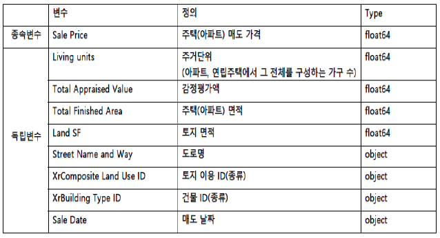

```python
Image('경금 자료/최종변수.png')
```

```python
# 연속형 변수 dtype 변환 object --> float64
df = df.astype({'landsf':'float64','totalfinishedarea':'float64','livingunits':'float64','saleprice':'float64','totalappraisedvalue':'float64'})
```

```python
df['saledate'] = pd.to_datetime(df['saledate']) # 시간 변수 전처리
```

```python
df['saledate'].sort_values().head() #2019.11 ~ 2021.01 까지의 시간 분포
```

```
0   2019-11-25 00:00:00+00:00
1   2019-11-25 00:00:00+00:00
2   2019-11-25 00:00:00+00:00
3   2019-11-25 00:00:00+00:00
4   2019-11-25 00:00:00+00:00
Name: saledate, dtype: datetime64[ns, UTC]
```

```python
# SaleDate --> Datetime 형식 변황 이후 연, 월 항목으로 분리 ( 시간변수의 영향력 확인할 목적)
df['saledate'] = df.saledate.apply(pd.to_datetime)
df['Year'] =  df.saledate.apply(lambda x : x.year)
df['Month'] =  df.saledate.apply(lambda x : x.month)
```

```python
# 서류 상의 명목형 변수 & 기존의 saledate 삭제
drop_columns = ['saledate','locationstartnumber','parcelid','apartmentunitnumber','ownerlastname','ownerfirstname','primarygrantor','legalreference','propertyid','xrprimaryneighborhoodid','xrsalesvalidityid','xrdeedid']
df = df.drop(drop_columns,axis=1)
```

```python
df.info() # 서류상 명목형 변수 제거 및 saledata를 연,월로 분리
```

```
<class 'pandas.core.frame.DataFrame'>
RangeIndex: 2835 entries, 0 to 2834
Data columns (total 10 columns):
 #   Column                Non-Null Count  Dtype
---  ------                --------------  -----
 0   xrcompositelanduseid  2835 non-null   object
 1   xrbuildingtypeid      2816 non-null   object
 2   streetnameandway      2835 non-null   object
 3   landsf                2575 non-null   float64
 4   totalfinishedarea     2730 non-null   float64
 5   livingunits           2816 non-null   float64
 6   saleprice             2835 non-null   float64
 7   totalappraisedvalue   2833 non-null   float64
 8   Year                  2835 non-null   int64
 9   Month                 2835 non-null   int64
dtypes: float64(5), int64(2), object(3)
memory usage: 221.6+ KB
```

```python
df = df.replace(0, np.NaN) # 모든 0값 결측값으로 대체
```

```python
pd.set_option('display.max_rows', None)
```

```python
df['saleprice'].sort_values().head()
# SalePrice에 0이외의 값들 중 결측치로 바꿔야 될 수치 파악 --> SalePrice 0,1,10
# 거래가격이 감정평가액과 지나치게 큰 차이를 보이는 값 ( 부동산 경제흐름 위반되는 값 )
```

```
806     1.0
991     1.0
614     1.0
613     1.0
2353    1.0
Name: saleprice, dtype: float64
```

```python
# saleprice 이상값을 null값으로 처리
df['saleprice'] = df['saleprice'].replace(0, np.NaN)
df['saleprice'] = df['saleprice'].replace(1, np.NaN)
df['saleprice'] = df['saleprice'].replace(10, np.NaN)
```

```python
print(df['xrbuildingtypeid'].mode()) #건물 타입(종류) --> 최빈값으로 결측값 채우기
df['xrbuildingtypeid'].fillna(16.0,inplace=True)
```

```
0    16
dtype: object
```

```python
df.isna().sum() # 결측값 채우기 이전 변수들의 결측값 수 확인
```

```
xrcompositelanduseid       0
xrbuildingtypeid           0
streetnameandway           0
landsf                  1325
totalfinishedarea        105
livingunits              238
saleprice               1145
totalappraisedvalue       16
Year                       0
Month                      0
dtype: int64
```

```python
# 최빈값 & 중앙값(변수 왜도 고려)
print('livingunits',df['livingunits'].mode())
print('landsf',df['landsf'].median())
print('totalfinishedarea',df['totalfinishedarea'].median())
print('totalappraisedvalue',df['totalappraisedvalue'].median())
print('saleprice',df['saleprice'].median())

#결측값 채우기
df['livingunits'].fillna(1.0,inplace=True) #최빈값
df['landsf'].fillna(7250.0,inplace=True) #중앙값
df['totalfinishedarea'].fillna(1353.5,inplace=True) #중앙값
df['totalappraisedvalue'].fillna(122100.0,inplace=True) #중앙값
df['saleprice'].fillna(255000.0,inplace=True) #중앙값
```

```
livingunits 0    1.0
dtype: float64
landsf 7250.0
totalfinishedarea 1353.5
totalappraisedvalue 122100.0
saleprice 255000.0
```

```python
df.isna().sum() # 연속형 자료 결측값 대체 이후 확인
```

```
xrcompositelanduseid    0
xrbuildingtypeid        0
streetnameandway        0
landsf                  0
totalfinishedarea       0
livingunits             0
saleprice               0
totalappraisedvalue     0
Year                    0
Month                   0
dtype: int64
```

```python
# 범주형 변수 처리 --> 더미변수 n-1개( 선형결합으로 인한 정보 중복 및 다중공선성 사전 완화)
df = pd.get_dummies(df,columns=['streetnameandway','xrcompositelanduseid','xrbuildingtypeid','Year','Month'],drop_first=True) #더미변수 함정 피하기(n-1개 범주)
```

```python
df.shape # 최종 데이터 크기
```

```
(2835, 504)
```

```python
#범주형 변수 499개 ['StreetNameAndWay','xrCompositeLandUseID','xrBuildingTypeID','Year','Month']
print(df.dtypes[df.dtypes != 'float64'].head())
len(df.dtypes[df.dtypes != 'float64'])
```

```
streetnameandway_ADAMS ST       uint8
streetnameandway_ADELAIDE ST    uint8
streetnameandway_AFFLECK ST     uint8
streetnameandway_AIRPORT RD     uint8
streetnameandway_ALBANY AVE     uint8
dtype: object
```

```
499
```

```python
#연속형 변수 5개 ['landsf','totalfinishedarea','livingunits','saleprice','totalappraisedvalue']
print(df.dtypes[df.dtypes == 'float64'])
len(df.dtypes[df.dtypes == 'float64'])
```

```
landsf                 float64
totalfinishedarea      float64
livingunits            float64
saleprice              float64
totalappraisedvalue    float64
dtype: object
```

```
5
```

```python
df.head() # 연속형 & 범주형으로 정리된 데이터
```

|  | landsf | totalfinishedarea | livingunits | saleprice | totalappraisedvalue | streetnameandway_ADAMS ST | streetnameandway_ADELAIDE ST | streetnameandway_AFFLECK ST | streetnameandway_AIRPORT RD | streetnameandway_ALBANY AVE | ... | Month_3 | Month_4 | Month_5 | Month_6 | Month_7 | Month_8 | Month_9 | Month_10 | Month_11 | Month_12 |
| --- | --- | --- | --- | --- | --- | --- | --- | --- | --- | --- | --- | --- | --- | --- | --- | --- | --- | --- | --- | --- | --- |
| 0 | 10000.0 | 4410.00000 | 2.0 | 255000.0 | 151700.0 | 0 | 0 | 0 | 0 | 0 | ... | 0 | 0 | 0 | 0 | 0 | 0 | 0 | 0 | 1 | 0 |
| 1 | 7840.0 | 1200.00000 | 1.0 | 156000.0 | 135500.0 | 0 | 0 | 0 | 0 | 0 | ... | 0 | 0 | 0 | 0 | 0 | 0 | 0 | 0 | 1 | 0 |
| 2 | 6600.0 | 3087.00000 | 3.0 | 255000.0 | 185600.0 | 0 | 0 | 0 | 0 | 0 | ... | 0 | 0 | 0 | 0 | 0 | 0 | 0 | 0 | 1 | 0 |
| 3 | 6600.0 | 3087.00000 | 3.0 | 255000.0 | 185600.0 | 0 | 0 | 0 | 0 | 0 | ... | 0 | 0 | 0 | 0 | 0 | 0 | 0 | 0 | 1 | 0 |
| 4 | 6810.0 | 2846.40001 | 3.0 | 229000.0 | 162900.0 | 0 | 0 | 0 | 0 | 0 | ... | 0 | 0 | 0 | 0 | 0 | 0 | 0 | 0 | 1 | 0 |

5 rows × 504 columns

```python
df[['landsf','totalfinishedarea','livingunits','saleprice','totalappraisedvalue']].describe() # 연속형 변수 요약통계량
```

|  | landsf | totalfinishedarea | livingunits | saleprice | totalappraisedvalue |
| --- | --- | --- | --- | --- | --- |
| count | 2835.000000 | 2835.000000 | 2835.000000 | 2.835000e+03 | 2.835000e+03 |
| mean | 9564.044797 | 3972.886025 | 2.229982 | 1.773713e+06 | 1.838580e+05 |
| std | 25983.355077 | 23490.287584 | 5.575492 | 7.729612e+06 | 8.053519e+05 |
| min | 432.000000 | 239.000000 | 1.000000 | 2.100000e+01 | 3.300000e+03 |
| 25% | 7000.000000 | 697.500000 | 1.000000 | 2.132500e+05 | 4.000000e+04 |
| 50% | 7250.000000 | 1353.500000 | 1.000000 | 2.550000e+05 | 1.221000e+05 |
| 75% | 7500.000000 | 3222.000000 | 2.000000 | 3.500000e+05 | 1.691500e+05 |
| max | 630313.000000 | 730457.920000 | 165.000000 | 6.050000e+07 | 2.702970e+07 |

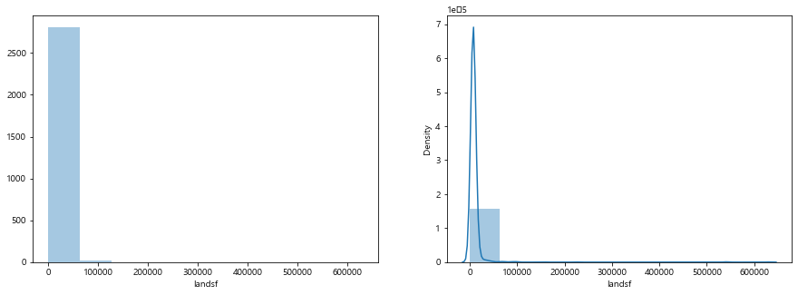

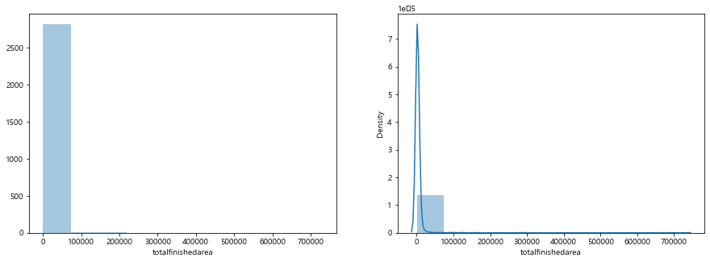

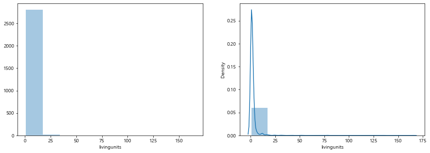

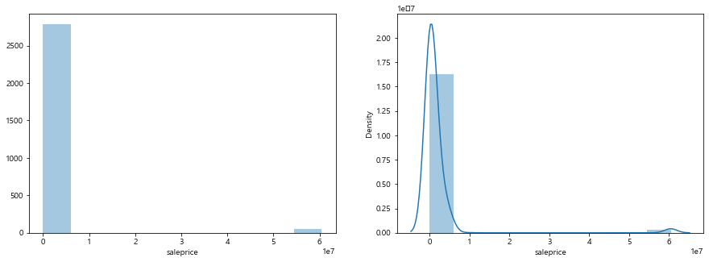

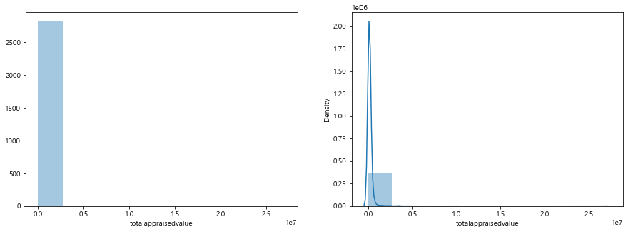

```python
# 연속형 변수의 확률분포 및 왜도 확인 --> 1.) 로그 변환 log1p(X) 고려
cols = df[['landsf','totalfinishedarea','livingunits','saleprice','totalappraisedvalue']].columns

for feature in cols:
    fig, ax = plt.subplots(ncols=2,figsize=(15,5))
    sns.distplot(df[feature], bins=10, kde=False,ax=ax[0])
    sns.distplot(df[feature], bins=10, kde=True,ax=ax[1])
```

```python
# 기존의 연속형 변수 왜도 이상 확인 --> 연속형 변수 로그 변환. Log1p(X)
features_index = df.dtypes[df.dtypes == 'float64'].index
skew_features = df[features_index].apply(lambda x:skew(x))
skew_features_top = skew_features[skew_features > 1]
print(skew_features_top.sort_values(ascending=False))
```

```
totalappraisedvalue    27.454492
totalfinishedarea      23.496271
landsf                 19.430418
livingunits            17.122038
saleprice               7.272033
dtype: float64
```

### 3. 모형 설명

- 회귀분석
- 트리 기반 알고리즘
- 평가지표

#### 3-1. 회귀분석

수집 및 전처리 작업이 완성된 데이터를 대상으로 일반적인 다중회귀, Lasso 회귀, Ridge 회귀, 그리고 ElasticNet 회귀 모형을 이용했다. 우선 예측에 있어서 다중회귀분석은 전통적인 회귀분석과 마찬가지로 데이터의 정규성이 충족되어야 회귀계수와 T통계량, 신뢰구간,p-value 등의 요소들이 신뢰성을 갖는다. 여기에 실제값과 예측값의 차이인 오차의 정규성과 등분산성이 만족되어야 올바른 해석이 가능하다. 또한, R2값이 높을수록 학습오차가 낮은 특징을 보인다.

#### 3-2. 트리 기반 알고리즘

트리 기반 알고리즘은 분류와 회귀에서 모두 사용되며 기본적으로 통계적 가정으로부터 제약을 받지 않고 이상치의 영향에서 상대적으로 자유롭다. 트리 기반 알고리즘에는 앙상블 학습이 있고 여기에는 배깅과 부스팅이 해당된다. 배깅은 알고리즘 수행마다 서로 다른 학습 데이터를 샘플링하여 사용하는 병렬적 처리이고 대표적으로 랜덤포레스트가 있다. 부스팅은 샘플을 뽑을 때 이전 모델에서의 오차의 가중치를 순차적으로 업데이트하며 여기에는 그레이디언트 부스팅, XG-Boost 등이 있다.

본 연구에서 사용된 랜덤포레스트 회귀모형은 충분한 학습을 거치고 검증에서의 과적합을 방지하기 위한 파라미터를 사용했다.사용된 트리의 개수(n_estimators)를 100개로 지정했고 나무의 최대 깊이(max_depth)를 10으로 지정했다.

그레이디언트부스팅 회귀는 우선 모형 자체가 잔차를 순차적으로 예측하는 특성을 지녔기 때문에 노이즈까지 학습하거나 과적합에 빠지기 쉬운 위험이 있다. 그레이디언트 부스팅에서 과적합을 방지하기 위한 방법 중 하나인 subsampling 기법을 이용해서 전체 데이터의 수를 줄였다. 여기서 subsample 파라미터는 0.8로 지정했고 n_estimators와 max_depth는 랜덤포레스트와 동일하게 지정했다.

XG-Boost 회귀는 그레이디언트 부스팅의 속도 및 과적합 규제를 어느 정도 해결할 수 있는 기법이다. 순차적인 잔차의 가중치를 조정하는 대신 병렬적 수행을 통해서 빠른 성능 수행을 가져오고 자체적으로 과적합 규제와 결손값 처리를 하는 등의 다재다능으로 여러 연구에서도 활발히 사용된다. 본 연구에서 XG-Boost회귀의 파라미터는 랜덤포레스트와 동일하게 지정했다.

#### 3-3. 평가지표

연속형 변수 예측에 있어서 종합적으로 성능들을 평가하기 위해서 평가지표는 한 가지 대신 4개를 사용했다. 이중 상대적으로 이상치에 덜 민감한 RMSE와 데이터의 단위의 덜 민감한 MAPE를 중심으로 모형들의 성능을 비교하는 데에 집중했다.

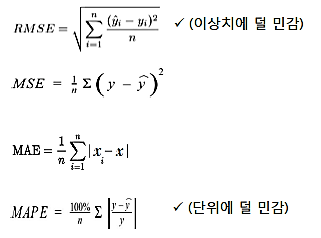

```python
Image('경금 자료/평가지표.png')
```

### 4. 결과

- 변수 선택
- 회귀 진단
- 모형 선택
- 중요도 분석

#### 4-3. 모형 선택

최종 선별된 77개의 변수들을 활용한 회귀 모형들의 성능 평가는 먼저 학습 데이터에 대한 K=10 fold 교차검증을 시행하고 검증 데이터에 대한 성능 평가로 이어졌다. 교차검증을 먼저 시행한 이유는 모형의 성능이 검증 데이터에만 좋게 나오는 위험을 사전에 파악하기 위해서였다. 학습 데이터에 대한 교차검증을 시행한 결과, 첫 번째 모형인 다중회귀분석의 RMSE 값들의 흐름은 상당히 불안정했다. RMSE값이 0.8이 나오는 경우도 있었지만, 매우 높은 수치도 다반사였다. 이러한 RMSE 값들은 그만큼 모형이 매우 불안정하고 아무리 해당 검증 데이터에서 성능이 좋다 하더라도 다른 데이터에서의 성능 평가에서 신뢰성이 떨어진다는 것을 의미한다. 이러한 문제는 다중공선성으로 인한 과적합으로 추측할 수 있었다. 반면, 나머지 규제 및 트리 기반 회귀 모형들의 각각의 10개의 RMSE 값들의 흐름은 모두 안정적이였다. 따라서 교차검증을 통한 모형의 경건함을 확인한 결과, 첫 번째 다중회귀분석 모형을 제외한 나머지 6개의 모형들로 검증 데이터에 대한 성능을 평가하게 되었다.

6개의 모형에 대한 검증 데이터의 성능을 확인한 결과, 통계적 가정 기반의 회귀모형과 트리 기반 회귀모형 중 RMSE와 MAPE를 기준으로 종합적으로 고려했을 때 Lasso회귀와 GBM(그레이디언트부스팅)회귀가 각각 RMSE 0.70 & MAPE 3.85, RMSE 0.60 & MAPE 2.75로 가장 좋은 모형으로 선정되었다. 이로써 종속변수 saleprice에 대한 예측력은 모두 충분히 좋은 수치로 나왔음을 확인했고 각 모형들의 변수 중요도 분석을 함께 시행했다. 변수 중요도 분석은 기존의 회귀모형의 경우 회귀계수의 순서, 트리 기반 회귀모형의 경우 SHAP-Value Plot을 이용했다. SHAP Value Plot이란 일반적인 중요도 분석과 다르게 변수의 방향성 및 양/음의 영향력을 함께 확인할 수 있어서 해석에 상당한 도움을 준다.

#### 4-4. 중요도 분석

우선, Lasso와 GBM에서 공통적으로 변수 중요도 상위권에 해당하는 streetnameandway_SOUTH MARSHALL_ST은 지역적 특성을 나타낸다. 해당 도로명으로 주변의 특성을 통합적이고 함축적으로 알 수 있는 점에서 기존의 선행연구 속 세부적인 지역적 특성과의 차이를 알 수 있다. 나아가 South_Marshall_ST를 구글맵으로 확대한 결과, 주변의 학교,회사, 그리고 편의시설과의 거리적 이점을 알 수 있었다.

객관적으로 성능이 좋은 다른 모형들에 대한 중요도 분석을 함께 시행한 결과, Ridge와 Lasso 회귀는 도로명 주소, 즉 함축적으로 지역적 특성을 나타내는 변수들이 아파트 가격에 영향을 끼치는 데에 있어서 최상위권으로 형성되었다. ElasticNet은 계절성 변수인 month_12(12월)과 토지 이용 종류(xrcompositelanduseid)가 최상위권을 이룬 것으로 보아 12월달에 매매가 가장 많이 이루어졌고 어떠한 토지 이용 목적에 따라 거래가 성사되었는지 추측할 수 있다. 또한, 랜덤포레스트와 XG-Boost의 경우 GBM과 공통적으로 month_12,xrcompositelanduseid_457,totalappraisedvalue, southmarshall_st가 최상위권에 형성된 것으로 보아 주택 가격 예측에 있어서 감정평가액(totalappraisedvalue)의 영향도 큰 연관성이 있음을 확인할 수 있다.

이를 통해서 랜덤포레스트,GBM, 그리고 XGBoost가 성능은 물론 변수의 중요도 분석에서도 기존의 회귀 모형보다 뛰어나다는 것을 알 수 있다. 특히 중요도 분석에 있어서 도로명 뿐만 아니라 다른 특성들을 통해서 보다 구체적인 예측 요인을 확인할 수 있는 장점이 드러났다.

```python
# SalePrice 예측
df['saleprice'] = np.log1p(df['saleprice']) # Target --> Log1p(X)
df['landsf'] = np.log1p(df['landsf']) # 연속형변수 --> Log1p(X)
df['livingunits'] = np.log1p(df['livingunits']) # 연속형변수 --> Log1p(X)
df['totalappraisedvalue'] = np.log1p(df['totalappraisedvalue']) # 연속형변수 --> Log1p(X)
df['totalfinishedarea'] = np.log1p(df['totalfinishedarea']) # 연속형변수 --> Log1p(X)
```

```python
X = df.drop('saleprice',axis=1,inplace=False)
y= df['saleprice']
```

```python
X_train,X_test,y_train,y_test = train_test_split(X,y,test_size=0.3,random_state=2021)
```

```python
def stepwise_selection(data, target,SL_in=0.05,SL_out = 0.05):
    initial_features = data.columns.tolist()
    best_features = []
    while (len(initial_features)>0):
        remaining_features = list(set(initial_features)-set(best_features))
        new_pval = pd.Series(index=remaining_features)
        for new_column in remaining_features:
            model = sm.OLS(target, sm.add_constant(data[best_features+[new_column]])).fit()
            new_pval[new_column] = model.pvalues[new_column]
        min_p_value = new_pval.min()
        if(min_p_value<SL_in):
            best_features.append(new_pval.idxmin())
            while(len(best_features)>0):
                best_features_with_constant = sm.add_constant(data[best_features])
                p_values = sm.OLS(target, best_features_with_constant).fit().pvalues[1:]
                max_p_value = p_values.max()
                if(max_p_value >= SL_out):
                    excluded_feature = p_values.idxmax()
                    best_features.remove(excluded_feature)
                else:
                    break
        else:
            break
    return best_features
```

```python
#stepwise_selection(X_train,y_train) #Stepwise Regression으로 통계적으로 유의한 변수만 우선 선택 (기준: p-value 0.05 이하)
```

[output not shown]

[output cut: 22 more lines]

```
 'xrcompositelanduseid_54',
 'streetnameandway_GUILFORD ST',
 'streetnameandway_GRAFTON ST',
 'xrcompositelanduseid_23',
 'xrcompositelanduseid_91',
 'streetnameandway_WAWARME AVE',
 'xrcompositelanduseid_53',
 'streetnameandway_ELM ST',
 'streetnameandway_WETHERSFIELD AVE',
 'xrbuildingtypeid_20',
 'streetnameandway_NEW BRITAIN AVE',
 'streetnameandway_ALLEN PL',
 'streetnameandway_CHARLOTTE ST',
 'xrbuildingtypeid_1',
 'streetnameandway_FLATBUSH AVE']
```

```python
step_features = ['Month_12','streetnameandway_SOUTH MARSHALL ST','xrcompositelanduseid_457','streetnameandway_FREDERICK ST','streetnameandway_SISSON AVE','xrcompositelanduseid_458','streetnameandway_BENTON ST','streetnameandway_COLLINS ST','streetnameandway_OWEN ST','streetnameandway_FARMINGTON AVE','streetnameandway_DENISON ST','streetnameandway_CAMBRIDGE ST','totalappraisedvalue','streetnameandway_NILES ST','streetnameandway_HUNTINGTON ST','streetnameandway_SUMNER ST','streetnameandway_HAMILTON CT','streetnameandway_TREMONT ST','streetnameandway_EVERGREEN AVE','streetnameandway_LAUREL ST','streetnameandway_LORRAINE ST','streetnameandway_PARK TER','xrcompositelanduseid_118','streetnameandway_FALES ST','streetnameandway_YALE ST','streetnameandway_GOLD ST','xrcompositelanduseid_7','xrcompositelanduseid_115','streetnameandway_PARK ST','xrcompositelanduseid_137','streetnameandway_SUMMIT ST','xrcompositelanduseid_127','streetnameandway_HARBISON AVE','streetnameandway_VERNON ST','xrbuildingtypeid_0','Month_10','xrbuildingtypeid_60','xrcompositelanduseid_61','xrcompositelanduseid_59','streetnameandway_HENRY ST','streetnameandway_WEST SERVICE RD','xrbuildingtypeid_84','xrcompositelanduseid_32','streetnameandway_MURPHY RD','streetnameandway_UNKNOWN','streetnameandway_BLUE HILLS AVE','streetnameandway_TOWNLEY ST','streetnameandway_CAPITOL AVE','streetnameandway_WINSHIP ST','Month_5','streetnameandway_VINELAND TER','streetnameandway_TRUMBULL ST','streetnameandway_FAIRMOUNT ST','streetnameandway_ZION ST','streetnameandway_WOLCOTT ST','xrcompositelanduseid_448','xrcompositelanduseid_447','xrcompositelanduseid_142','streetnameandway_CEDAR ST','streetnameandway_WELLINGTON ST','xrbuildingtypeid_44','streetnameandway_MOUNTFORD ST','xrcompositelanduseid_54','streetnameandway_GUILFORD ST','streetnameandway_GRAFTON ST','xrcompositelanduseid_23','xrcompositelanduseid_91','streetnameandway_WAWARME AVE','xrcompositelanduseid_53','streetnameandway_ELM ST','streetnameandway_WETHERSFIELD AVE','xrbuildingtypeid_20','streetnameandway_NEW BRITAIN AVE','streetnameandway_ALLEN PL','streetnameandway_CHARLOTTE ST','xrbuildingtypeid_1','streetnameandway_FLATBUSH AVE']
len(step_features) # 503 --> 77개로 1차 변수 축소 (속도증가 & 과적합 방지 목적)
```

```
77
```

```python
X_train2 = X_train[step_features] # 77개의 설명변수
X_test2 = X_test[step_features] # 77개의 설명변수
```

```python
X2 = sm.add_constant(X_train2) #Adj. R-squared:0.788 --> 0.798로 증가. 학습시 설명변수의 영향력 증가 & 학습 오차 감소
model = sm.OLS(y_train, X2)
result = model.fit()
print( result.summary() )
```

```
                            OLS Regression Results
==============================================================================
Dep. Variable:              saleprice   R-squared:                       0.806
Model:                            OLS   Adj. R-squared:                  0.798
Method:                 Least Squares   F-statistic:                     111.6
Date:                Sat, 18 Dec 2021   Prob (F-statistic):               0.00
Time:                        20:47:21   Log-Likelihood:                -1867.0
No. Observations:                1984   AIC:                             3878.
Df Residuals:                    1912   BIC:                             4281.
Df Model:                          71
Covariance Type:            nonrobust
======================================================================================================
                                         coef    std err          t      P>|t|      [0.025      0.975]
------------------------------------------------------------------------------------------------------
const                                  5.0468      0.360     14.030      0.000       4.341       5.752
Month_12                               0.5005      0.044     11.250      0.000       0.413       0.588
streetnameandway_SOUTH MARSHALL ST     2.4418      0.131     18.650      0.000       2.185       2.699
xrcompositelanduseid_457               1.3668      0.071     19.287      0.000       1.228       1.506
streetnameandway_FREDERICK ST          4.0543      0.225     17.988      0.000       3.612       4.496
streetnameandway_SISSON AVE            3.3578      0.199     16.870      0.000       2.967       3.748
xrcompositelanduseid_458               1.2080      0.087     13.812      0.000       1.036       1.380
streetnameandway_BENTON ST             2.0378      0.099     20.569      0.000       1.844       2.232
streetnameandway_COLLINS ST            2.2513      0.113     19.987      0.000       2.030       2.472
streetnameandway_OWEN ST               2.3638      0.167     14.119      0.000       2.035       2.692
streetnameandway_FARMINGTON AVE        2.3658      0.190     12.474      0.000       1.994       2.738
streetnameandway_DENISON ST            3.9826      0.380     10.491      0.000       3.238       4.727
streetnameandway_CAMBRIDGE ST         -6.1732      0.633     -9.750      0.000      -7.415      -4.931
totalappraisedvalue                    0.5890      0.030     19.645      0.000       0.530       0.648
streetnameandway_NILES ST              3.0523      0.194     15.733      0.000       2.672       3.433
streetnameandway_HUNTINGTON ST         1.9000      0.147     12.933      0.000       1.612       2.188
streetnameandway_SUMNER ST             1.6698      0.116     14.412      0.000       1.443       1.897
streetnameandway_HAMILTON CT           3.5641      0.437      8.162      0.000       2.708       4.421
streetnameandway_TREMONT ST           -2.6390      0.284     -9.302      0.000      -3.195      -2.083
streetnameandway_EVERGREEN AVE         1.0846      0.100     10.842      0.000       0.888       1.281
streetnameandway_LAUREL ST             1.2950      0.116     11.149      0.000       1.067       1.523
streetnameandway_LORRAINE ST           5.1433      0.633      8.124      0.000       3.902       6.385
streetnameandway_PARK TER              1.8210      0.215      8.489      0.000       1.400       2.242
xrcompositelanduseid_118               0.8271      0.294      2.814      0.005       0.251       1.403
streetnameandway_FALES ST              1.2627      0.195      6.490      0.000       0.881       1.644
streetnameandway_YALE ST              -2.4535      0.366     -6.710      0.000      -3.171      -1.736
```

[output cut: 48 more lines]

```
streetnameandway_ALLEN PL             -0.1945      0.098     -1.991      0.047      -0.386      -0.003
streetnameandway_CHARLOTTE ST          0.4445      0.225      1.979      0.048       0.004       0.885
xrbuildingtypeid_1                     0.4445      0.225      1.979      0.048       0.004       0.885
streetnameandway_FLATBUSH AVE         -0.6260      0.319     -1.962      0.050      -1.252      -0.000
==============================================================================
Omnibus:                      704.783   Durbin-Watson:                   1.933
Prob(Omnibus):                  0.000   Jarque-Bera (JB):             8500.593
Skew:                          -1.319   Prob(JB):                         0.00
Kurtosis:                      12.792   Cond. No.                     2.46e+17
==============================================================================

Notes:
[1] Standard Errors assume that the covariance matrix of the errors is correctly specified.
[2] The smallest eigenvalue is 4.38e-30. This might indicate that there are
strong multicollinearity problems or that the design matrix is singular.
```

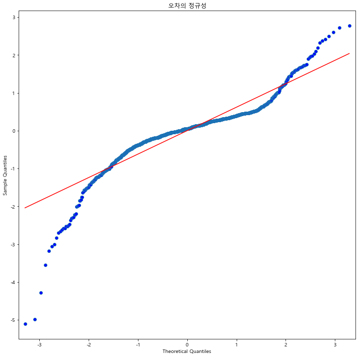

```python
#회귀 성립 조건1. 오차의 정규성 확인
model_residuals = result.resid

plt.rcParams['axes.unicode_minus'] = False
fig, ax = plt.subplots(1,1)
fig.set_figheight(12)
fig.set_figwidth(12)

sm.ProbPlot(model_residuals).qqplot(line='s',color='#1f77b4',ax=ax)
ax.title.set_text('오차의 정규성')
```

[output not shown]

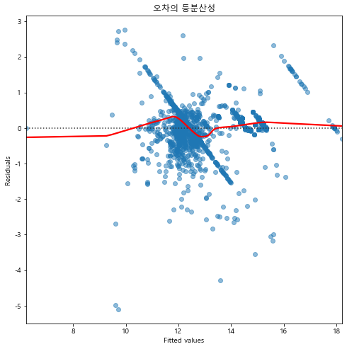

```python
#회귀 성립 조건2. 오차의 등분산성 확인
model_fitted_y = result.fittedvalues

fig, ax = plt.subplots(1,1)
fig.set_figheight(8)
fig.set_figwidth(8)

sns.residplot(model_fitted_y,y_train,data=X_train2,lowess=True,scatter_kws={'alpha':0.5},
              line_kws={'color':'red'},ax=ax)
ax.title.set_text('오차의 등분산성')
ax.set(xlabel='Fitted values',ylabel='Residuals')
```

```python
#L1,L2,ElasticNet 파라미터 찾기
from sklearn.model_selection import GridSearchCV

Ridge_reg = Ridge(random_state=2021) # L2규제
Lasso_reg = Lasso(random_state=2021) # L1 규제
Elast = ElasticNet(random_state=2021) # (L1+ L2) --> L1에 L2규제 적용

def print_best_params(model,params):
    grid_model = GridSearchCV(model,param_grid=params,scoring='neg_mean_squared_error',cv=10)
    grid_model.fit(X_train2,y_train)
    rmse = np.sqrt(-1*grid_model.best_score_)
    print('{0} K=Fold  최적 평균 RMSE 값:{1}, 최적 alpha:{2}'.format(model.__class__.__name__,np.round(rmse,2),grid_model.best_params_))

Ridge_params = {'alpha':[0.05,0.1,1,5,8,10,12,15,20]}
Lasso_params = {'alpha':[0.001,0.05,0.03,0.1,0.5,1,5,10,20,50,100]}
Elast_params = {'alpha':[0.05,0.1,0.5,1,5,8,10,12,15,20,50,100]}
print_best_params(Ridge_reg,Ridge_params)
print_best_params(Lasso_reg,Lasso_params)
print_best_params(Elast,Elast_params)
```

```
Ridge K=Fold  최적 평균 RMSE 값:0.73, 최적 alpha:{'alpha': 1}
Lasso K=Fold  최적 평균 RMSE 값:0.73, 최적 alpha:{'alpha': 0.001}
ElasticNet K=Fold  최적 평균 RMSE 값:1.04, 최적 alpha:{'alpha': 0.05}
```

```python
lr_reg = LinearRegression()
Ridge_reg = Ridge(alpha=1,random_state=2021)
Lasso_reg = Lasso(alpha=0.001,random_state=2021)
elastic_net = ElasticNet(alpha=0.05, l1_ratio=0.001, random_state=42)
rf_reg = RandomForestRegressor(random_state=0,n_estimators=100,max_depth=10) #최소한의 파라미터 수정 --> 깊이, 트리 집합 개수
gbm_reg = GradientBoostingRegressor(random_state=0,n_estimators=100,max_depth=10,subsample=0.8) #최소한의 파라미터 수정 --> 깊이, 트리 집합 개수
xgb_reg = XGBRegressor(random_state=0,n_estimators=100,max_depth=10) #최소한의 파라미터 수정 --> 깊이, 트리 집합 개수
```

```python
# 모델 교차검증 성능(K=10Fold 시행) --> Baseline 회귀 RMSE 흐름 매우 불안정 [ 과적합 발생으로 판단]
def get_avg_rmse_cv(models):

    for model in models:
        rmse_list = np.sqrt(-cross_val_score(model,X_train2,y_train,scoring='neg_mean_squared_error',cv=10))
        rmse_avg = np.mean(rmse_list)
        print('\n{0} K=10 RMSE List:{1}'.format(model.__class__.__name__,np.round(rmse_list,2)))
        print('\n{0} K=10 Mean RMSE List:{1}'.format(model.__class__.__name__,np.round(rmse_avg,2)))
        print('------------------------------------------------------------------------------------')
        print('------------------------------------------------------------------------------------')

models = [lr_reg,Ridge_reg,Lasso_reg,elastic_net,rf_reg,gbm_reg,xgb_reg]
get_avg_rmse_cv(models)
```

```
LinearRegression K=10 RMSE List:[3.53829671e+07 8.40000000e-01 5.16760965e+10 3.59974457e+06
 3.52617449e+07 1.38568000e+03 5.30000000e-01 1.34107332e+11
 1.26423055e+06 5.13198000e+03]

LinearRegression K=10 Mean RMSE List:18585894378.3
------------------------------------------------------------------------------------
------------------------------------------------------------------------------------

Ridge K=10 RMSE List:[0.71 0.84 0.67 0.62 0.77 0.62 0.53 0.95 0.71 0.74]

Ridge K=10 Mean RMSE List:0.72
------------------------------------------------------------------------------------
------------------------------------------------------------------------------------

Lasso K=10 RMSE List:[0.72 0.84 0.68 0.63 0.8  0.63 0.55 0.95 0.72 0.74]

Lasso K=10 Mean RMSE List:0.73
------------------------------------------------------------------------------------
------------------------------------------------------------------------------------

ElasticNet K=10 RMSE List:[1.17 1.16 0.76 0.77 1.13 0.92 0.74 1.06 0.94 1.  ]

ElasticNet K=10 Mean RMSE List:0.96
------------------------------------------------------------------------------------
------------------------------------------------------------------------------------

RandomForestRegressor K=10 RMSE List:[0.69 0.8  0.68 0.6  0.68 0.52 0.42 0.82 0.67 0.56]

RandomForestRegressor K=10 Mean RMSE List:0.64
------------------------------------------------------------------------------------
------------------------------------------------------------------------------------

GradientBoostingRegressor K=10 RMSE List:[0.69 0.76 0.76 0.62 0.66 0.54 0.41 0.83 0.64 0.59]

GradientBoostingRegressor K=10 Mean RMSE List:0.65
------------------------------------------------------------------------------------
------------------------------------------------------------------------------------

XGBRegressor K=10 RMSE List:[0.69 0.83 0.83 0.68 0.73 0.58 0.45 0.79 0.64 0.61]

XGBRegressor K=10 Mean RMSE List:0.68
------------------------------------------------------------------------------------
------------------------------------------------------------------------------------
```

|  | mean RMSE | rmse std |
| --- | --- | --- |
| Ridge | 0.716 | 0.119648 |
| Lasso | 0.726 | 0.115682 |
| ElNet | 0.965 | 0.166950 |
| RF | 0.644 | 0.122583 |
| GBM | 0.650 | 0.121381 |
| XGB | 0.683 | 0.119727 |

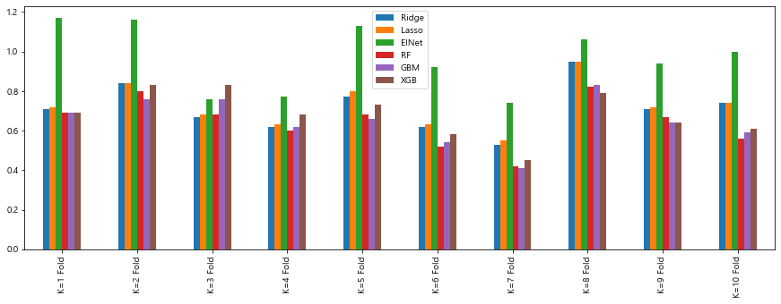

```python
Score = {'Ridge':[0.71, 0.84, 0.67, 0.62 ,0.77, 0.62, 0.53, 0.95, 0.71, 0.74],
         'Lasso':[0.72 ,0.84, 0.68, 0.63, 0.8 , 0.63, 0.55 ,0.95 ,0.72 ,0.74],
         'ElNet':[1.17 ,1.16, 0.76, 0.77, 1.13 ,0.92, 0.74, 1.06 ,0.94 ,1.0 ],
         'RF': [0.69 ,0.8,  0.68, 0.6,  0.68, 0.52 ,0.42, 0.82, 0.67 ,0.56],
         'GBM':[0.69, 0.76, 0.76, 0.62, 0.66, 0.54, 0.41, 0.83 ,0.64, 0.59],
         'XGB':[0.69 ,0.83, 0.83, 0.68, 0.73, 0.58, 0.45, 0.79, 0.64 ,0.61 ]}


results = pd.DataFrame(Score,index=['K=1 Fold','K=2 Fold','K=3 Fold','K=4 Fold','K=5 Fold','K=6 Fold','K=7 Fold','K=8 Fold','K=9 Fold','K=10 Fold'])
ax = results.plot.bar(figsize=(15,5)) #평균 RMSE
pd.concat([results.mean(),results.std()],axis=1,keys=['mean RMSE',' rmse std']) #모형 선택
```

```python
for model in [Ridge_reg,Lasso_reg,elastic_net,rf_reg,gbm_reg,xgb_reg]: # Test set에 대한 성능
    get_model_predict(model,X_train2.values,X_test2.values,y_train.values,y_test.values)
```

```
-----------------------------------------------
Ridge
MSE:0.500000,RMSE:0.710000,MAE:0.450000,MAPE:3.880000
-----------------------------------------------
Lasso
MSE:0.480000,RMSE:0.700000,MAE:0.450000,MAPE:3.850000
-----------------------------------------------
ElasticNet
MSE:0.890000,RMSE:0.940000,MAE:0.640000,MAPE:5.240000
-----------------------------------------------
RandomForestRegressor
MSE:0.330000,RMSE:0.580000,MAE:0.330000,MAPE:2.820000
-----------------------------------------------
GradientBoostingRegressor
MSE:0.350000,RMSE:0.600000,MAE:0.320000,MAPE:2.750000
-----------------------------------------------
XGBRegressor
MSE:0.420000,RMSE:0.640000,MAE:0.340000,MAPE:2.930000
```

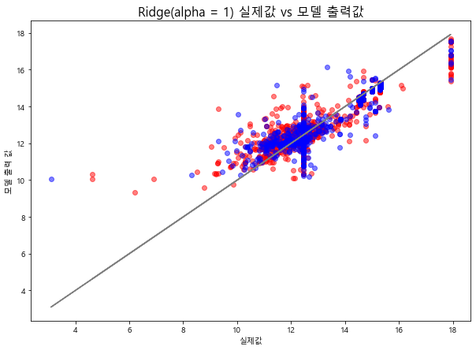

```python
model = Ridge_reg.fit(X_train2,y_train)
pred_train = model.predict(X_train2)
pred_test = model.predict(X_test2)


import matplotlib.font_manager as fm
plt.rc('font',family="Malgun Gothic")

plt.figure(figsize=(10,7))
plt.title('Ridge(alpha = 1) 실제값 vs 모델 출력값',fontsize=16)
plt.scatter(y_train,pred_train,c='red',alpha=0.5) #alpha 투명도 0일수록 투명
plt.scatter(y_test,pred_test,c='blue',alpha=0.5)
plt.plot(y_test,y_test,c='gray')
plt.plot(y_train,y_train,c='gray')
plt.xlabel('실제값',size=10)
plt.ylabel('모델 출력 값',size=10)
plt.show()
```

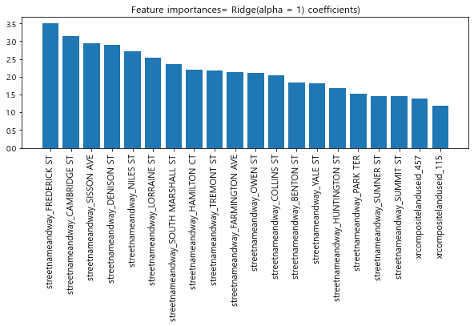

```python
model = Ridge_reg.fit(X_train2,y_train)
coef_df = pd.DataFrame(model.coef_.reshape(-1,1),index=X_test2.columns,columns=['coefficients'])

coefficients = np.abs(coef_df.coefficients)
index = np.argsort(coefficients)[::-1]

importance = coefficients[index]
columns = [list(coef_df.index)[i] for i in index]

importance = importance[importance>0]

num_print =20

plt.figure(figsize=(10,3))
plt.title('Feature importances= Ridge(alpha = 1) coefficients)')
plt.bar(range(num_print),importance[:num_print],align='center')
plt.xticks(range(num_print),columns[:num_print],rotation=90,fontsize=11)
plt.show()
```

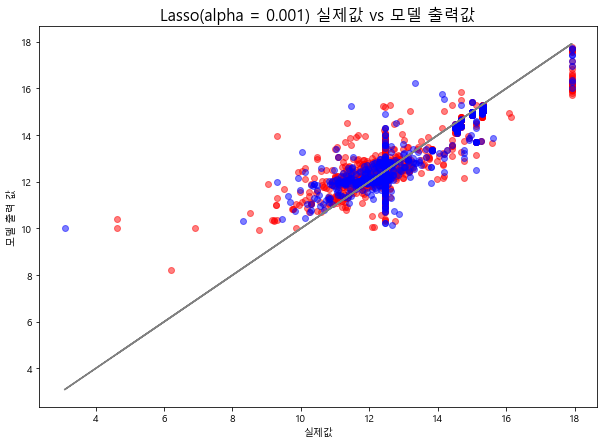

```python
model = Lasso_reg.fit(X_train2,y_train)
pred_train = model.predict(X_train2)
pred_test = model.predict(X_test2)


import matplotlib.font_manager as fm
plt.rc('font',family="Malgun Gothic")

plt.figure(figsize=(10,7))
plt.title('Lasso(alpha = 0.001) 실제값 vs 모델 출력값',fontsize=16)
plt.scatter(y_train,pred_train,c='red',alpha=0.5) #alpha 투명도 0일수록 투명
plt.scatter(y_test,pred_test,c='blue',alpha=0.5)
plt.plot(y_test,y_test,c='gray')
plt.plot(y_train,y_train,c='gray')
plt.xlabel('실제값',size=10)
plt.ylabel('모델 출력 값',size=10)
plt.show()
```

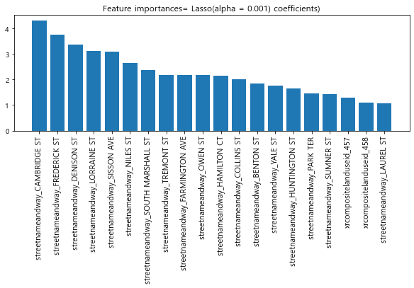

```python
model = Lasso_reg.fit(X_train2,y_train)
coef_df = pd.DataFrame(model.coef_.reshape(-1,1),index=X_test2.columns,columns=['coefficients'])

coefficients = np.abs(coef_df.coefficients)
index = np.argsort(coefficients)[::-1]

importance = coefficients[index]
columns = [list(coef_df.index)[i] for i in index]

importance = importance[importance>0]

num_print =20

plt.figure(figsize=(10,3))
plt.title('Feature importances= Lasso(alpha = 0.001) coefficients)')
plt.bar(range(num_print),importance[:num_print],align='center')
plt.xticks(range(num_print),columns[:num_print],rotation=90,fontsize=11)
plt.show()
```

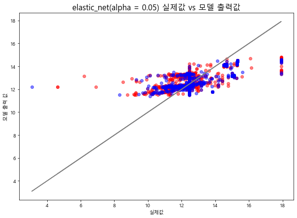

```python
model = elastic_net.fit(X_train2,y_train)
pred_train = model.predict(X_train2)
pred_test = model.predict(X_test2)


import matplotlib.font_manager as fm
plt.rc('font',family="Malgun Gothic")

plt.figure(figsize=(10,7))
plt.title('elastic_net(alpha = 0.05) 실제값 vs 모델 출력값',fontsize=16)
plt.scatter(y_train,pred_train,c='red',alpha=0.5) #alpha 투명도 0일수록 투명
plt.scatter(y_test,pred_test,c='blue',alpha=0.5)
plt.plot(y_test,y_test,c='gray')
plt.plot(y_train,y_train,c='gray')
plt.xlabel('실제값',size=10)
plt.ylabel('모델 출력 값',size=10)
plt.show()
```

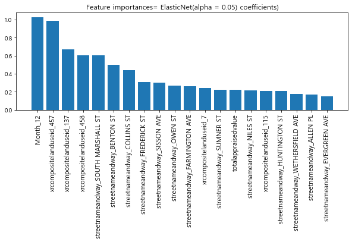

```python
model = elastic_net.fit(X_train2,y_train)
coef_df = pd.DataFrame(model.coef_.reshape(-1,1),index=X_test2.columns,columns=['coefficients'])

coefficients = np.abs(coef_df.coefficients)
index = np.argsort(coefficients)[::-1]

importance = coefficients[index]
columns = [list(coef_df.index)[i] for i in index]

importance = importance[importance>0]

num_print =20

plt.figure(figsize=(10,3))
plt.title('Feature importances= ElasticNet(alpha = 0.05) coefficients)')
plt.bar(range(num_print),importance[:num_print],align='center')
plt.xticks(range(num_print),columns[:num_print],rotation=90,fontsize=11)
plt.show()
```

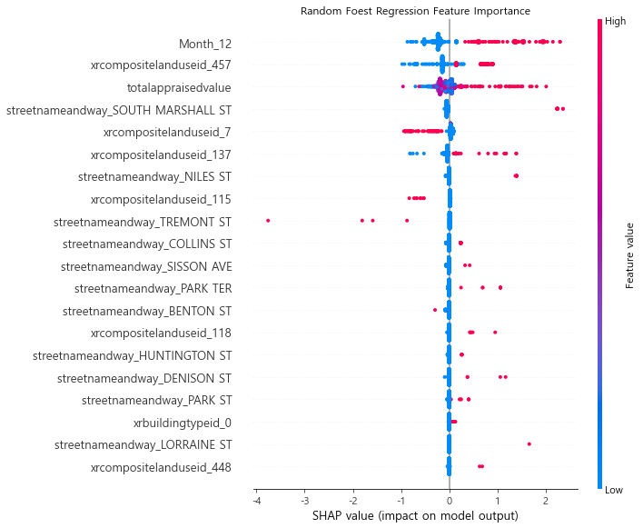

```python
import shap
plt.title('Random Foest Regression Feature Importance')
explainer = shap.TreeExplainer(rf_reg)
shap_values = explainer.shap_values(X_test2)
shap.summary_plot(shap_values, X_test2)
plt.show()
```

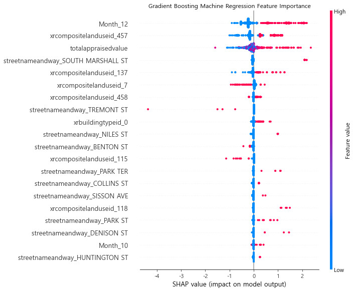

```python
plt.title('Gradient Boosting Machine Regression Feature Importance')
explainer = shap.TreeExplainer(gbm_reg)
shap_values = explainer.shap_values(X_test2)
shap.summary_plot(shap_values, X_test2)
plt.show()
```

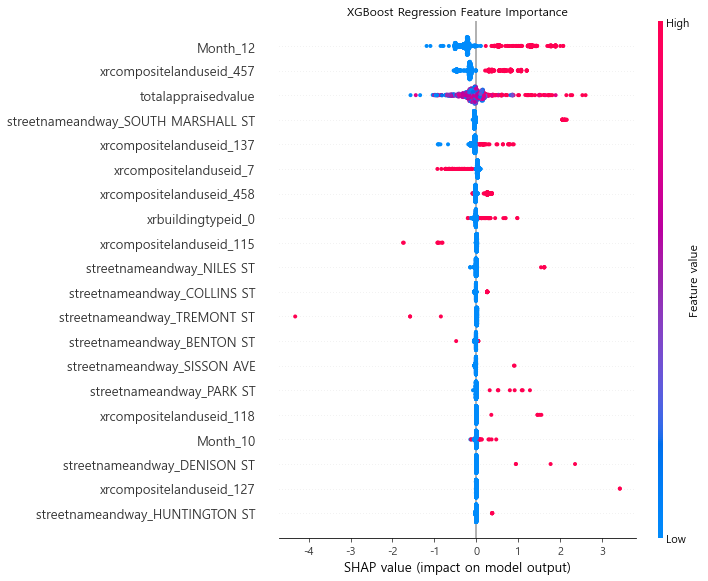

```python
plt.title('XGBoost Regression Feature Importance')
explainer = shap.TreeExplainer(xgb_reg)
shap_values = explainer.shap_values(X_test2)
shap.summary_plot(shap_values, X_test2)
plt.show()
```

[figure not shown]

```python
Image('경금 자료/southmarshall_st.png')
```

### 5. 결론

- 결론
- 한계
- 향후 연구방향

#### 5-1. 결론

본 연구의 결론은 다음과 같다. 우선 규제를 적용한 회귀모형과 트리 기반의 모형들의 성능에 대한 경건함을 교차검증을 사전에 진행하면서 확인할 수 있었다. 또한, 선행연구와 마찬가지로 주택 가격 예측에 있어서 지역적 특성의 높은 중요도를 볼 수 있었다. Hartford 공공데이터에서 지역적 특성을 나타낸 변수는 streetnameandway였으며 특히 연구 모형 중 Ridge와 Lasso 회귀의 변수 중요도 분석에서 도로명 주소가 최상위권에 전부 포진되어 있었다. 물론 다른 모형들에서도 도로명 주소는 중요한 영향력을 보이지만, Ridge & Lasso와는 다르게 최상위권에 형성된 중요 변수들의 특징은 획일적이지 않았고 비교적 다채로웠다. 특히 랜덤포레스트,GBM 그리고 XGBoost의 경우 계절성, 토지 이용 종류, 감정평가액, 도로명주소(Sout_Marshall_ST)가 예측에 있어서 가장 중요한 변수로 선정되었다. 이 점을 통해서 보다 주택 가격을 예측하는 데에 있어서 다양한 요소를 고려한 결과가 출력되었다고 해석할 수 있고 선행연구와의 가장 큰 차별점이라고 볼 수 있다.

#### 5-2. 한계

본 연구의 한계점은 다음과 같다. 가장 큰 한계점은 우선 부족한 데이터의 크기이다. 해당 데이터는 2835개의 행에 불과하다. 따라서 이에 따라 충분하지 못한 학습이 이루어졌다는 우려가 있다. 특히 부족한 데이터로 인한 계절성의 특징이 뚜렷하기 못한 점이 있었다. Csv파일로 제공하는 과거 데이터 약 4000개의 행을 추가했지만 특별히 달라진 점은 없었다. 또한, 범주형 변수에 대한 더미변수 변환을 시행했을 때, 기존에 지역 및 건물 특성의 변수들이 가장 많았기 때문에 변수 중요도 분석에서 상위권에 포진된 경향이 있었다. 하지만 Hartford 데이터 속 해당 특성들은 선행연구의 변수들에 비해서 세분화가 전혀 되어 있지 않은 수준이라고 할 수 있을 만큼 매우 단편적으로 나타났기 때문에 모형들의 성능 역시 상대적으로 좋지 않았다. 물론 함축적이고 간결하게 특성을 파악할 수 있는 장점은 있지만 이러한 간결함은 주택 가격 예측에 있어서 상대적으로 단점으로 적용되었다. 또한, Lasso와 GBM에서 공통적으로 상위권에 속한 South_Marshall_ST의 Carriage Place 아파트에 대한 평점을 확인한 결과, 5점 만점 중 평균 1.5점에 불과했고 주민들의 불만사항이 상당했다. 이것은 단순히 수치형 변수만으로 주택 가격을 예측하는 것이 생각보다 폭넓은 해석과는 거리가 있음을 알 수 있다.

#### 5-3. 향후 연구방향

부동산 시장에서 주택 가격의 예측은 해당 지역도 물론 중요하지만 타 지역과의 비교에도 역시 상당한 영향력을 받는다. 따라서, Connecticut 주 소속 다른 도시의 주택 가격 공공데이터를 함께 활용해서 연구의 해석력과 설득력을 높일 수 있을 것으로 기대된다. 또한, 결과에서 totalappraisedvalue(감정평가액)이 주요 변수로 나타난 점으로 보아 이러한 부동산 특성 변수의 수집 역시 보다 부동산 시장의 흐름을 보여줄 수 있을 것으로 보인다. 마지막으로 텍스트 및 이미지 형식 등 다양한 종류의 데이터를 수집해서 보편적인 수치형 및 범주형 데이터의 한계를 보완할 수 있다.